# Formation R — Séance 2 : Manipulation et visualisation de données

Tidyverse, ggplot2, structures de données avancées et statistiques

Auteur·rice

Date de publication

# Introduction

Bienvenue dans la **Séance 2** de cette formation R ! Lors de la première séance, vous avez acquis les bases essentielles : installation de R et RStudio, calculs arithmétiques, création de variables, types de données, vecteurs, data frames, importation de données et premiers graphiques.

Cette deuxième séance, d’une durée de **5 heures**, vous plonge dans les outils modernes de la communauté R : le **tidyverse**, la manipulation avancée des structures de données et la visualisation professionnelle avec **ggplot2**.

**NotePrérequis — Ce que vous devez maîtriser avant cette séance**

✅ Créer et manipuler des vecteurs et data frames

✅ Utiliser les fonctions de base : `mean()`, `sum()`, `table()`, `class()`

✅ Importer un fichier Excel avec `readxl`

✅ Produire un histogramme et un diagramme en barres

Si l’un de ces points n’est pas clair, relisez le support de la Séance 1 avant de continuer.

# Objectifs de la séance

**NoteCompétences visées — Séance 2**

✅ **Installer et charger** les packages du tidyverse

✅ **Manipuler** des données avec `dplyr` : filtrer, sélectionner, transformer, résumer

✅ **Remodeler** des tableaux avec `tidyr` : format long ↔︎ large

✅ **Créer et manipuler** des listes et des facteurs

✅ **Comprendre** les vecteurs labellisés et leur intérêt en enquête

✅ **Produire** des graphiques publiables avec `ggplot2`

✅ **Calculer** des statistiques univariées et bivariées avec les fonctions de base

✅ **Utiliser** des fonctions utilitaires essentielles de R

# 1 Introduction au Tidyverse

## 1.1 Qu’est-ce que le Tidyverse ?

Le **tidyverse** est une collection de packages R conçus pour travailler ensemble de façon cohérente. Tous partagent la même philosophie : les données doivent être **ordonnées** (*tidy*) pour faciliter l’analyse.

Un jeu de données est dit *tidy* lorsque :

1. Chaque **variable** occupe une colonne
2. Chaque **observation** occupe une ligne
3. Chaque **valeur** occupe une cellule

**ImportantÀ retenir — Les packages principaux du Tidyverse**

| Package | Rôle principal |
| --- | --- |
| `dplyr` | Manipulation de données (filtrer, trier, résumer…) |
| `tidyr` | Remise en forme des tableaux (pivot, gather…) |
| `ggplot2` | Visualisation de données |
| `readr` | Importation de fichiers CSV et texte |
| `stringr` | Manipulation de chaînes de caractères |
| `forcats` | Manipulation de facteurs |
| `purrr` | Programmation fonctionnelle |
| `tibble` | Amélioration des data frames |

## 1.2 Installation et chargement

```r
# Installation du tidyverse (une seule fois)
install.packages("tidyverse")
```

```r
# Chargement du tidyverse (à chaque session)
library(tidyverse)
```

**AstuceAstuce — `library(tidyverse)` charge plusieurs packages à la fois**

En tapant `library(tidyverse)`, vous chargez automatiquement : `ggplot2`, `dplyr`, `tidyr`, `readr`, `purrr`, `tibble`, `stringr` et `forcats`. C’est équivalent à charger ces 8 packages un par un.

## 1.3 Le tibble : version améliorée du data frame

Le **tibble** est la version moderne du data frame dans le tidyverse. Il s’affiche mieux dans la console et gère mieux les types de données.

```r
# Créer un tibble
donnees_eleves <- tibble(
  nom     = c("Adjoua", "Kofi", "Aminata", "Brice", "Fatouma"),
  age     = c(22, 24, 21, 23, 20),
  filiere = c("Statistique", "Démographie", "Statistique", "Info", "Éco"),
  note    = c(14.5, 11.0, 16.5, 13.0, 12.5)
)

donnees_eleves
```

```
# A tibble: 5 × 4
  nom       age filiere      note
  <chr>   <dbl> <chr>       <dbl>
1 Adjoua     22 Statistique  14.5
2 Kofi       24 Démographie  11
3 Aminata    21 Statistique  16.5
4 Brice      23 Info         13
5 Fatouma    20 Éco          12.5
```

```r
# Différence avec un data.frame classique à l'affichage
class(donnees_eleves)
```

```
[1] "tbl_df"     "tbl"        "data.frame"
```

## 1.4 L’opérateur pipe `|>`

Le **pipe** (`|>`) est l’un des éléments les plus importants du tidyverse. Il permet de chaîner des opérations de gauche à droite, rendant le code beaucoup plus lisible.

```r
# Sans pipe : lecture de droite à gauche, difficile à suivre
round(mean(c(12, 14, 11, 16, 13)), 2)
```

```
[1] 13.2
```

```r
# Avec pipe : lecture de gauche à droite, naturelle
c(12, 14, 11, 16, 13) |> mean() |> round(2)
```

```
[1] 13.2
```

**AstuceRaccourci clavier pour le pipe**

Dans RStudio : **`Ctrl + Shift + M`** insère le pipe `|>`

L’ancien pipe `%>%` du package `magrittr` fonctionne de la même façon. Vous le verrez souvent dans les tutoriels anciens.

# 2 Manipulation de données avec `dplyr`

`dplyr` fournit un ensemble de **verbes** pour manipuler les données. Chaque verbe effectue une action précise et peut être chaîné avec le pipe.

## 2.1 Jeu de données de travail

```r
# Jeu de données : enquête dans une université
set.seed(42)
n <- 80

enquete <- tibble(
  id           = 1:n,
  sexe         = sample(c("Homme", "Femme"), n, replace = TRUE, prob = c(0.55, 0.45)),
  age          = sample(18:30, n, replace = TRUE),
  filiere      = sample(c("Statistique", "Démographie", "Informatique", "Économie"),
                        n, replace = TRUE),
  annee        = sample(1:3, n, replace = TRUE),
  note_stats   = round(runif(n, 5, 20), 1),
  note_info    = round(runif(n, 5, 20), 1),
  heures_travail = sample(1:8, n, replace = TRUE),
  bourse       = sample(c(TRUE, FALSE), n, replace = TRUE, prob = c(0.4, 0.6))
)

glimpse(enquete)
```

```
Rows: 80
Columns: 9
$ id             <int> 1, 2, 3, 4, 5, 6, 7, 8, 9, 10, 11, 12, 13, 14, 15, 16, …
$ sexe           <chr> "Femme", "Femme", "Homme", "Femme", "Femme", "Homme", "…
$ age            <int> 21, 30, 27, 26, 30, 29, 21, 26, 28, 20, 30, 22, 29, 25,…
$ filiere        <chr> "Démographie", "Démographie", "Informatique", "Démograp…
$ annee          <int> 1, 1, 2, 3, 3, 3, 1, 1, 1, 2, 3, 3, 1, 3, 2, 3, 2, 3, 3…
$ note_stats     <dbl> 13.4, 14.8, 9.2, 19.7, 14.7, 13.7, 14.2, 18.9, 10.9, 9.…
$ note_info      <dbl> 14.8, 18.8, 10.4, 17.8, 9.5, 12.0, 7.1, 17.1, 15.0, 5.9…
$ heures_travail <int> 1, 3, 1, 4, 3, 3, 5, 6, 5, 3, 5, 2, 6, 4, 2, 7, 4, 1, 1…
$ bourse         <lgl> FALSE, FALSE, TRUE, FALSE, FALSE, FALSE, TRUE, FALSE, F…
```

## 2.2 `filter()` — Filtrer les lignes

```r
# Étudiants de première année
enquete |> filter(annee == 1)
```

```
# A tibble: 27 × 9
      id sexe    age filiere    annee note_stats note_info heures_travail bourse
   <int> <chr> <int> <chr>      <int>      <dbl>     <dbl>          <int> <lgl>
 1     1 Femme    21 Démograph…     1       13.4      14.8              1 FALSE
 2     2 Femme    30 Démograph…     1       14.8      18.8              3 FALSE
 3     7 Femme    21 Informati…     1       14.2       7.1              5 TRUE
 4     8 Homme    26 Démograph…     1       18.9      17.1              6 FALSE
 5     9 Femme    28 Démograph…     1       10.9      15                5 FALSE
 6    13 Femme    29 Économie       1       16.4      15.5              6 TRUE
 7    20 Femme    25 Économie       1       17.4      17.7              4 FALSE
 8    21 Femme    18 Démograph…     1       13.7      10.9              1 FALSE
 9    22 Homme    19 Statistiq…     1       12.1       6.2              3 FALSE
10    25 Homme    24 Statistiq…     1       14         6.7              3 FALSE
# ℹ 17 more rows
```

```r
# Étudiants de Statistique ayant une note > 14
enquete |> filter(filiere == "Statistique", note_stats > 14)
```

```
# A tibble: 4 × 9
     id sexe    age filiere     annee note_stats note_info heures_travail bourse
  <int> <chr> <int> <chr>       <int>      <dbl>     <dbl>          <int> <lgl>
1    16 Femme    29 Statistique     3       19.5       9.6              7 TRUE
2    35 Homme    30 Statistique     3       15.8      12.4              5 FALSE
3    38 Homme    20 Statistique     2       18.6      18.6              6 FALSE
4    69 Femme    20 Statistique     2       15.3      18.5              6 TRUE
```

```r
# Étudiants boursiers OU ayant plus de 25 ans
enquete |> filter(bourse == TRUE | age > 25) |> nrow()
```

```
[1] 48
```

## 2.3 `select()` — Sélectionner les colonnes

```r
# Sélectionner quelques colonnes
enquete |> select(id, sexe, filiere, note_stats)
```

```
# A tibble: 80 × 4
      id sexe  filiere      note_stats
   <int> <chr> <chr>             <dbl>
 1     1 Femme Démographie        13.4
 2     2 Femme Démographie        14.8
 3     3 Homme Informatique        9.2
 4     4 Femme Démographie        19.7
 5     5 Femme Économie           14.7
 6     6 Homme Économie           13.7
 7     7 Femme Informatique       14.2
 8     8 Homme Démographie        18.9
 9     9 Femme Démographie        10.9
10    10 Femme Informatique        9.3
# ℹ 70 more rows
```

```r
# Exclure des colonnes avec -
enquete |> select(-id, -bourse)
```

```
# A tibble: 80 × 7
   sexe    age filiere      annee note_stats note_info heures_travail
   <chr> <int> <chr>        <int>      <dbl>     <dbl>          <int>
 1 Femme    21 Démographie      1       13.4      14.8              1
 2 Femme    30 Démographie      1       14.8      18.8              3
 3 Homme    27 Informatique     2        9.2      10.4              1
 4 Femme    26 Démographie      3       19.7      17.8              4
 5 Femme    30 Économie         3       14.7       9.5              3
 6 Homme    29 Économie         3       13.7      12                3
 7 Femme    21 Informatique     1       14.2       7.1              5
 8 Homme    26 Démographie      1       18.9      17.1              6
 9 Femme    28 Démographie      1       10.9      15                5
10 Femme    20 Informatique     2        9.3       5.9              3
# ℹ 70 more rows
```

```r
# Sélection par type ou pattern
enquete |> select(starts_with("note"))     # colonnes qui commencent par "note"
```

```
# A tibble: 80 × 2
   note_stats note_info
        <dbl>     <dbl>
 1       13.4      14.8
 2       14.8      18.8
 3        9.2      10.4
 4       19.7      17.8
 5       14.7       9.5
 6       13.7      12
 7       14.2       7.1
 8       18.9      17.1
 9       10.9      15
10        9.3       5.9
# ℹ 70 more rows
```

```r
enquete |> select(where(is.numeric))       # toutes les colonnes numériques
```

```
# A tibble: 80 × 6
      id   age annee note_stats note_info heures_travail
   <int> <int> <int>      <dbl>     <dbl>          <int>
 1     1    21     1       13.4      14.8              1
 2     2    30     1       14.8      18.8              3
 3     3    27     2        9.2      10.4              1
 4     4    26     3       19.7      17.8              4
 5     5    30     3       14.7       9.5              3
 6     6    29     3       13.7      12                3
 7     7    21     1       14.2       7.1              5
 8     8    26     1       18.9      17.1              6
 9     9    28     1       10.9      15                5
10    10    20     2        9.3       5.9              3
# ℹ 70 more rows
```

## 2.4 `mutate()` — Créer ou modifier des colonnes

```r
# Ajouter une colonne "moyenne" et une colonne "mention"
enquete <- enquete |>
  mutate(
    moyenne = (note_stats + note_info) / 2,
    mention = case_when(
      moyenne >= 16 ~ "Très bien",
      moyenne >= 14 ~ "Bien",
      moyenne >= 12 ~ "Assez bien",
      moyenne >= 10 ~ "Passable",
      TRUE          ~ "Insuffisant"
    )
  )

# Vérification
enquete |> select(id, note_stats, note_info, moyenne, mention) |> head(8)
```

```
# A tibble: 8 × 5
     id note_stats note_info moyenne mention
  <int>      <dbl>     <dbl>   <dbl> <chr>
1     1       13.4      14.8    14.1 Bien
2     2       14.8      18.8    16.8 Très bien
3     3        9.2      10.4     9.8 Insuffisant
4     4       19.7      17.8    18.8 Très bien
5     5       14.7       9.5    12.1 Assez bien
6     6       13.7      12      12.8 Assez bien
7     7       14.2       7.1    10.6 Passable
8     8       18.9      17.1    18   Très bien
```

## 2.5 `arrange()` — Trier les lignes

```r
# Trier par moyenne décroissante
enquete |> arrange(desc(moyenne)) |> select(id, filiere, moyenne, mention) |> head(5)
```

```
# A tibble: 5 × 4
     id filiere     moyenne mention
  <int> <chr>         <dbl> <chr>
1    47 Démographie    19.0 Très bien
2     4 Démographie    18.8 Très bien
3    38 Statistique    18.6 Très bien
4    45 Démographie    18.3 Très bien
5     8 Démographie    18   Très bien
```

```r
# Trier par filière puis par moyenne décroissante
enquete |> arrange(filiere, desc(moyenne)) |>
  select(id, filiere, moyenne) |> head(8)
```

```
# A tibble: 8 × 3
     id filiere     moyenne
  <int> <chr>         <dbl>
1    47 Démographie    19.0
2     4 Démographie    18.8
3    45 Démographie    18.3
4     8 Démographie    18
5     2 Démographie    16.8
6    37 Démographie    16.7
7    63 Démographie    16.2
8    26 Démographie    16.0
```

## 2.6 `summarise()` — Résumer les données

```r
# Statistiques globales
enquete |>
  summarise(
    n          = n(),
    moy_stats  = mean(note_stats),
    moy_info   = mean(note_info),
    moy_gen    = mean(moyenne),
    et_gen     = sd(moyenne),
    min_gen    = min(moyenne),
    max_gen    = max(moyenne)
  )
```

```
# A tibble: 1 × 7
      n moy_stats moy_info moy_gen et_gen min_gen max_gen
  <int>     <dbl>    <dbl>   <dbl>  <dbl>   <dbl>   <dbl>
1    80      11.9     12.0    12.0   3.39     5.7    19.0
```

## 2.7 `group_by()` + `summarise()` — Statistiques par groupe

C’est la combinaison la plus puissante de `dplyr` : calculer des statistiques **par groupe**.

```r
# Statistiques par filière
enquete |>
  group_by(filiere) |>
  summarise(
    n          = n(),
    moy_gen    = round(mean(moyenne), 2),
    moy_stats  = round(mean(note_stats), 2),
    pct_bourse = round(mean(bourse) * 100, 1)
  ) |>
  arrange(desc(moy_gen))
```

```
# A tibble: 4 × 5
  filiere          n moy_gen moy_stats pct_bourse
  <chr>        <int>   <dbl>     <dbl>      <dbl>
1 Démographie     25    13.5      13.6       20
2 Économie        19    12.1      11.2       31.6
3 Statistique     20    11.0      11.2       25
4 Informatique    16    10.8      11.2       50
```

```r
# Statistiques par sexe et par filière
enquete |>
  group_by(sexe, filiere) |>
  summarise(
    n     = n(),
    moy   = round(mean(moyenne), 2),
    .groups = "drop"
  ) |>
  arrange(filiere, sexe)
```

```
# A tibble: 8 × 4
  sexe  filiere          n   moy
  <chr> <chr>        <int> <dbl>
1 Femme Démographie     13 13.8
2 Homme Démographie     12 13.2
3 Femme Informatique    10  9.36
4 Homme Informatique     6 13.1
5 Femme Statistique      7 10.7
6 Homme Statistique     13 11.1
7 Femme Économie        10 13.0
8 Homme Économie         9 11.1
```

**ImportantÀ retenir — Les 5 verbes fondamentaux de `dplyr`**

| Verbe | Action |
| --- | --- |
| `filter()` | Garder certaines **lignes** selon une condition |
| `select()` | Garder ou exclure certaines **colonnes** |
| `mutate()` | Créer ou transformer des **colonnes** |
| `arrange()` | **Trier** les lignes |
| `summarise()` + `group_by()` | **Résumer** par groupe |

## 2.8 `count()` — Compter rapidement

```r
# Compter les effectifs par filière
enquete |> count(filiere, sort = TRUE)
```

```
# A tibble: 4 × 2
  filiere          n
  <chr>        <int>
1 Démographie     25
2 Statistique     20
3 Économie        19
4 Informatique    16
```

```r
# Compter avec proportions
enquete |>
  count(filiere) |>
  mutate(pct = round(n / sum(n) * 100, 1))
```

```
# A tibble: 4 × 3
  filiere          n   pct
  <chr>        <int> <dbl>
1 Démographie     25  31.2
2 Informatique    16  20
3 Statistique     20  25
4 Économie        19  23.8
```

## 2.9 `rename()` et `relocate()`

```r
# Renommer une colonne
enquete |> rename(note_statistique = note_stats) |> names()
```

```
 [1] "id"               "sexe"             "age"              "filiere"
 [5] "annee"            "note_statistique" "note_info"        "heures_travail"
 [9] "bourse"           "moyenne"          "mention"
```

```r
# Déplacer une colonne en premier
enquete |> relocate(moyenne, .before = note_stats) |> names()
```

```
 [1] "id"             "sexe"           "age"            "filiere"
 [5] "annee"          "moyenne"        "note_stats"     "note_info"
 [9] "heures_travail" "bourse"         "mention"
```

# 3 Listes et tableaux de données

## 3.1 Les listes en R

Une **liste** est une structure qui peut contenir des éléments de types différents : vecteurs, data frames, d’autres listes, etc. C’est la structure la plus flexible de R.

```r
# Créer une liste hétérogène
profil_etudiant <- list(
  nom        = "Adjoa Mensah",
  age        = 22,
  notes      = c(14.5, 12.0, 16.0, 11.5),
  est_bourse = TRUE,
  adresse    = list(ville = "Parakou", pays = "Bénin")
)

# Afficher la structure
str(profil_etudiant)
```

```
List of 5
 $ nom       : chr "Adjoa Mensah"
 $ age       : num 22
 $ notes     : num [1:4] 14.5 12 16 11.5
 $ est_bourse: logi TRUE
 $ adresse   :List of 2
  ..$ ville: chr "Parakou"
  ..$ pays : chr "Bénin"
```

## 3.2 Accéder aux éléments d’une liste

```r
# Méthode 1 : par le nom avec $
profil_etudiant$nom
```

```
[1] "Adjoa Mensah"
```

```r
profil_etudiant$notes
```

```
[1] 14.5 12.0 16.0 11.5
```

```r
# Méthode 2 : par double crochets [[]]
profil_etudiant[["age"]]
```

```
[1] 22
```

```r
# Méthode 3 : par position
profil_etudiant[[1]]   # Premier élément
```

```
[1] "Adjoa Mensah"
```

```r
# Accès imbriqué
profil_etudiant$adresse$ville
```

```
[1] "Parakou"
```

```r
# Longueur d'une liste
length(profil_etudiant)
```

```
[1] 5
```

```r
# Noms des éléments
names(profil_etudiant)
```

```
[1] "nom"        "age"        "notes"      "est_bourse" "adresse"
```

## 3.3 Modifier une liste

```r
# Ajouter un élément
profil_etudiant$filiere <- "Statistique Appliquée"

# Modifier un élément
profil_etudiant$age <- 23

# Supprimer un élément
profil_etudiant$est_bourse <- NULL

str(profil_etudiant)
```

```
List of 5
 $ nom    : chr "Adjoa Mensah"
 $ age    : num 23
 $ notes  : num [1:4] 14.5 12 16 11.5
 $ adresse:List of 2
  ..$ ville: chr "Parakou"
  ..$ pays : chr "Bénin"
 $ filiere: chr "Statistique Appliquée"
```

## 3.4 Listes de data frames (tableaux imbriqués)

```r
# Cas pratique : résultats de plusieurs enquêtes
resultats <- list(
  ue1 = tibble(matiere = "Statistique", note = c(14, 12, 16, 11, 15)),
  ue2 = tibble(matiere = "Informatique", note = c(13, 15, 12, 17, 14)),
  ue3 = tibble(matiere = "Démographie",  note = c(11, 14, 13, 15, 12))
)

# Accéder à un tableau
resultats$ue1
```

```
# A tibble: 5 × 2
  matiere      note
  <chr>       <dbl>
1 Statistique    14
2 Statistique    12
3 Statistique    16
4 Statistique    11
5 Statistique    15
```

```r
# Calculer la moyenne pour chaque UE
sapply(resultats, function(df) mean(df$note))
```

```
 ue1  ue2  ue3
13.6 14.2 13.0
```

## 3.5 `tidyr` — Remise en forme des tableaux

Le package `tidyr` permet de passer d’un format **large** (une ligne par individu, plusieurs colonnes de mesures) à un format **long** (une ligne par mesure), et vice-versa.

```r
# Données en format large
notes_large <- tibble(
  etudiant = c("Adjoua", "Kofi", "Aminata", "Brice"),
  stats    = c(14.5, 11.0, 16.5, 13.0),
  info     = c(13.0, 15.0, 12.0, 14.5),
  demo     = c(12.0, 10.5, 14.0, 11.5)
)
notes_large
```

```
# A tibble: 4 × 4
  etudiant stats  info  demo
  <chr>    <dbl> <dbl> <dbl>
1 Adjoua    14.5  13    12
2 Kofi      11    15    10.5
3 Aminata   16.5  12    14
4 Brice     13    14.5  11.5
```

```r
# Passage au format long avec pivot_longer()
notes_long <- notes_large |>
  pivot_longer(
    cols      = c(stats, info, demo),  # colonnes à empiler
    names_to  = "matiere",             # nom de la nouvelle colonne des noms
    values_to = "note"                 # nom de la nouvelle colonne des valeurs
  )
notes_long
```

```
# A tibble: 12 × 3
   etudiant matiere  note
   <chr>    <chr>   <dbl>
 1 Adjoua   stats    14.5
 2 Adjoua   info     13
 3 Adjoua   demo     12
 4 Kofi     stats    11
 5 Kofi     info     15
 6 Kofi     demo     10.5
 7 Aminata  stats    16.5
 8 Aminata  info     12
 9 Aminata  demo     14
10 Brice    stats    13
11 Brice    info     14.5
12 Brice    demo     11.5
```

```r
# Retour au format large avec pivot_wider()
notes_large_retour <- notes_long |>
  pivot_wider(
    names_from  = matiere,
    values_from = note
  )
notes_large_retour
```

```
# A tibble: 4 × 4
  etudiant stats  info  demo
  <chr>    <dbl> <dbl> <dbl>
1 Adjoua    14.5  13    12
2 Kofi      11    15    10.5
3 Aminata   16.5  12    14
4 Brice     13    14.5  11.5
```

**AstuceQuand utiliser le format long vs large ?**

- **Format large** : présentation dans un tableau, rapport, export Excel
- **Format long** : analyse avec `dplyr`, visualisation avec `ggplot2`, modélisation

La plupart des fonctions du tidyverse travaillent avec le **format long**.

# 4 Facteurs et vecteurs labellisés

## 4.1 Les facteurs (`factor`)

Un **facteur** est un vecteur de valeurs catégorielles dont les niveaux sont fixés et ordonnés. C’est le type utilisé pour représenter des variables qualitatives en R.

```r
# Créer un facteur simple
niveau_etude <- factor(c("Licence", "Master", "Licence", "Doctorat", "Master"))
niveau_etude
```

```
[1] Licence  Master   Licence  Doctorat Master
Levels: Doctorat Licence Master
```

```r
# Voir les niveaux
levels(niveau_etude)
```

```
[1] "Doctorat" "Licence"  "Master"
```

```r
# Nombre de niveaux
nlevels(niveau_etude)
```

```
[1] 3
```

```r
# Classe
class(niveau_etude)
```

```
[1] "factor"
```

## 4.2 Facteurs ordonnés

```r
# Facteur ordonné (avec hiérarchie)
mention <- factor(
  c("Bien", "Passable", "Très bien", "Assez bien", "Bien"),
  levels  = c("Passable", "Assez bien", "Bien", "Très bien"),
  ordered = TRUE
)
mention
```

```
[1] Bien       Passable   Très bien  Assez bien Bien
Levels: Passable < Assez bien < Bien < Très bien
```

```r
# Comparaison logique possible grâce à l'ordre
mention[1] > mention[2]   # "Bien" > "Passable" ?
```

```
[1] TRUE
```

## 4.3 Le package `forcats` pour manipuler les facteurs

`forcats` (inclus dans le tidyverse) fournit des fonctions pratiques pour gérer les facteurs.

```r
# Données avec un facteur filière
filieres_vec <- c("Statistique", "Éco", "Info", "Statistique", "Démographie",
                  "Éco", "Info", "Statistique", "Statistique", "Éco")
filiere_f <- factor(filieres_vec)

# fct_count() : compter les modalités
fct_count(filiere_f, sort = TRUE)
```

```
# A tibble: 4 × 2
  f               n
  <fct>       <int>
1 Statistique     4
2 Éco             3
3 Info            2
4 Démographie     1
```

```r
# fct_relevel() : réordonner les niveaux manuellement
filiere_f <- fct_relevel(filiere_f, "Statistique", "Démographie", "Éco", "Info")
levels(filiere_f)
```

```
[1] "Statistique" "Démographie" "Éco"         "Info"
```

```r
# fct_recode() : renommer les modalités
filiere_f2 <- fct_recode(filiere_f,
  "STAT" = "Statistique",
  "DEMO" = "Démographie",
  "INFO" = "Info",
  "ECO"  = "Éco"
)
levels(filiere_f2)
```

```
[1] "STAT" "DEMO" "ECO"  "INFO"
```

```r
# fct_lump_n() : regrouper les modalités rares
region <- factor(c("Borgou", "Atacora", "Borgou", "Atlantique", "Borgou",
                   "Zou", "Couffo", "Borgou", "Atlantique", "Mono", "Borgou"))
# Garder les 2 plus fréquentes, regrouper le reste en "Autre"
fct_lump_n(region, n = 2)
```

```
 [1] Borgou     Other      Borgou     Atlantique Borgou     Other
 [7] Other      Borgou     Atlantique Other      Borgou
Levels: Atlantique Borgou Other
```

## 4.4 Les vecteurs labellisés

Les **vecteurs labellisés** permettent d’associer des **étiquettes textuelles** à des **codes numériques**, comme dans les logiciels d’enquête (Stata, SPSS, SAS). C’est très utile pour les données d’enquêtes ménages.

```r
# Installation du package haven (si nécessaire)
install.packages("haven")
```

```r
library(haven)

# Créer un vecteur labellisé
sexe_lab <- labelled(
  c(1, 2, 1, 1, 2, 2, 1),
  labels = c(Homme = 1, Femme = 2)
)

sexe_lab
```

```
<labelled<double>[7]>
[1] 1 2 1 1 2 2 1

Labels:
 value label
     1 Homme
     2 Femme
```

```r
class(sexe_lab)
```

```
[1] "haven_labelled" "vctrs_vctr"     "double"
```

```r
# Voir les labels
attr(sexe_lab, "labels")
```

```
Homme Femme
    1     2
```

```r
# Convertir en facteur
as_factor(sexe_lab)
```

```
[1] Homme Femme Homme Homme Femme Femme Homme
Levels: Homme Femme
```

```r
# Exemple complet : données d'enquête codées
niveau_vie <- labelled(
  c(1, 3, 2, 1, 4, 2, 3, 1),
  labels = c(
    "Très pauvre" = 1,
    "Pauvre"      = 2,
    "Moyen"       = 3,
    "Aisé"        = 4
  )
)

# Affichage avec les labels
as_factor(niveau_vie)
```

```
[1] Très pauvre Moyen       Pauvre      Très pauvre Aisé        Pauvre
[7] Moyen       Très pauvre
Levels: Très pauvre Pauvre Moyen Aisé
```

```r
# Table de fréquences avec labels
table(as_factor(niveau_vie))
```

```
Très pauvre      Pauvre       Moyen        Aisé
          3           2           2           1
```

**NoteVecteurs labellisés vs Facteurs**

|  | Facteur | Vecteur labellisé |
| --- | --- | --- |
| Stockage interne | Entier | Numérique avec attributs |
| Usage principal | Analyse R native | Import depuis Stata/SPSS |
| Package | Base R | `haven` |
| Conversion | `as.factor()` | `as_factor()` (haven) |

Dans la pratique, on importe les données Stata/SPSS avec `haven`, et on convertit en facteurs pour l’analyse avec `as_factor()`.

# 5 Visualisation avec `ggplot2`

## 5.1 La grammaire des graphiques

`ggplot2` est fondé sur la **grammaire des graphiques** : tout graphique est construit par couches successives.

```
ggplot(data = ..., aes(x = ..., y = ..., color = ...)) +
  geom_...() +           # type de graphique
  scale_...() +          # ajustement des axes/couleurs
  labs(...) +            # titres et labels
  theme_...()            # apparence générale
```

**ImportantÀ retenir — Les 3 composantes obligatoires**

1. **`data`** : le jeu de données
2. **`aes()`** : les aesthetics (variables mappées aux axes, couleurs, formes…)
3. **`geom_*()`** : le type de représentation graphique

## 5.2 Histogramme avec `geom_histogram()`

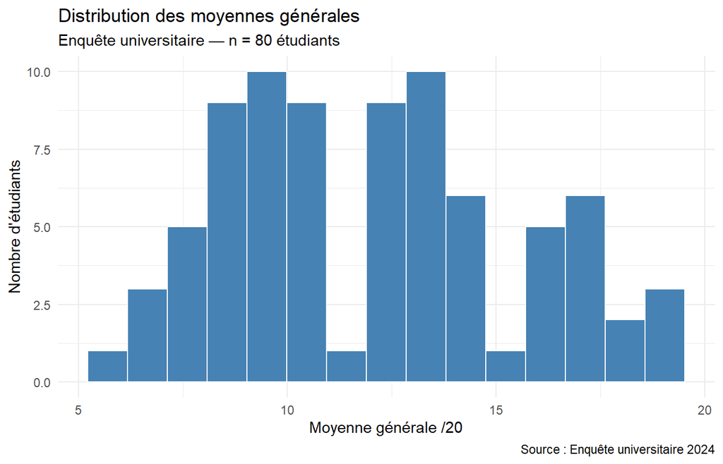

```r
ggplot(enquete, aes(x = moyenne)) +
  geom_histogram(bins = 15, fill = "steelblue", color = "white") +
  labs(
    title    = "Distribution des moyennes générales",
    subtitle = "Enquête universitaire — n = 80 étudiants",
    x        = "Moyenne générale /20",
    y        = "Nombre d'étudiants",
    caption  = "Source : Enquête universitaire 2024"
  ) +
  theme_minimal()
```

## 5.3 Diagramme en barres avec `geom_bar()`

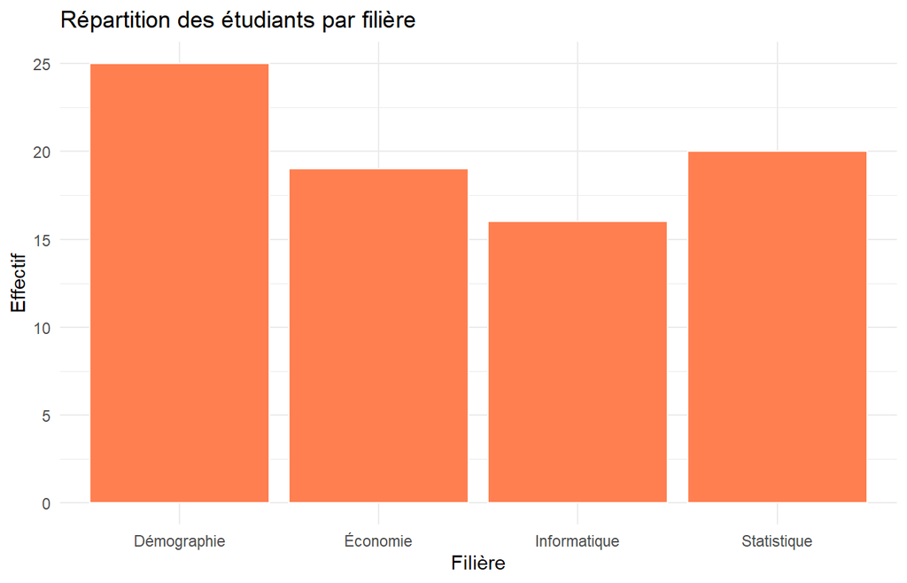

```r
ggplot(enquete, aes(x = filiere)) +
  geom_bar(fill = "coral", color = "white") +
  labs(
    title = "Répartition des étudiants par filière",
    x     = "Filière",
    y     = "Effectif"
  ) +
  theme_minimal()
```

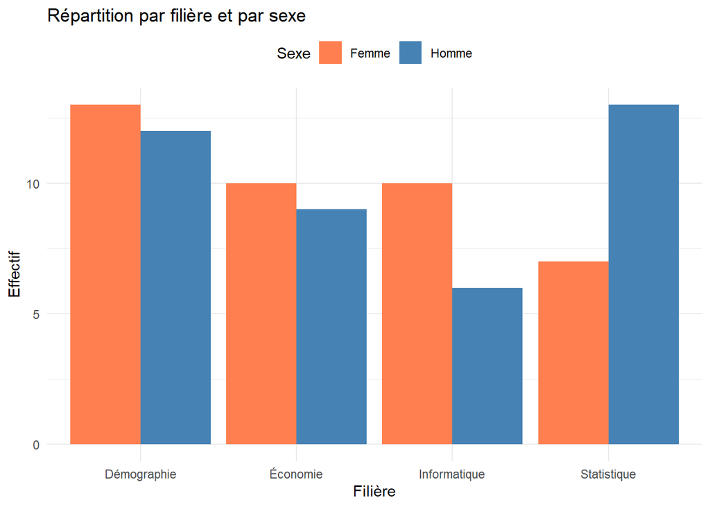

```r
# Barres groupées par sexe
ggplot(enquete, aes(x = filiere, fill = sexe)) +
  geom_bar(position = "dodge") +
  scale_fill_manual(values = c("Homme" = "steelblue", "Femme" = "coral")) +
  labs(
    title = "Répartition par filière et par sexe",
    x     = "Filière",
    y     = "Effectif",
    fill  = "Sexe"
  ) +
  theme_minimal() +
  theme(legend.position = "top")
```

## 5.4 Boîte à moustaches avec `geom_boxplot()`

La boîte à moustaches (boxplot) est idéale pour comparer la distribution d’une variable quantitative selon les modalités d’une variable qualitative.

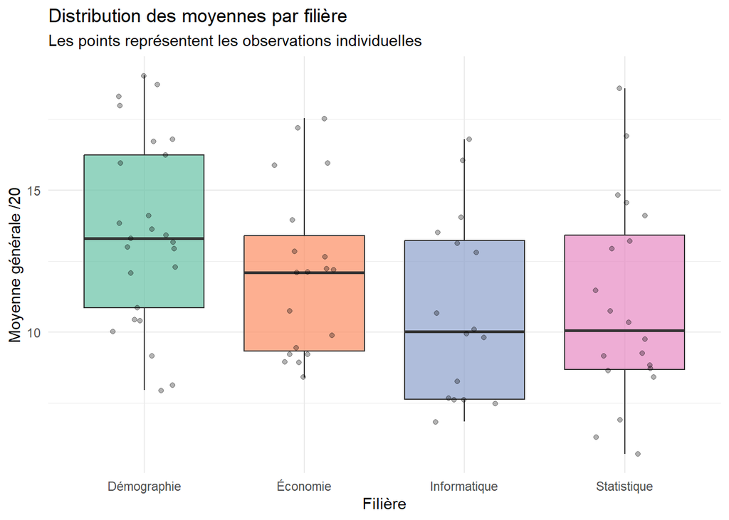

```r
ggplot(enquete, aes(x = filiere, y = moyenne, fill = filiere)) +
  geom_boxplot(alpha = 0.7) +
  geom_jitter(width = 0.2, alpha = 0.3, size = 1.5) +  # points individuels
  scale_fill_brewer(palette = "Set2") +
  labs(
    title    = "Distribution des moyennes par filière",
    subtitle = "Les points représentent les observations individuelles",
    x        = "Filière",
    y        = "Moyenne générale /20"
  ) +
  theme_minimal() +
  theme(legend.position = "none")
```

## 5.5 Nuage de points avec `geom_point()`

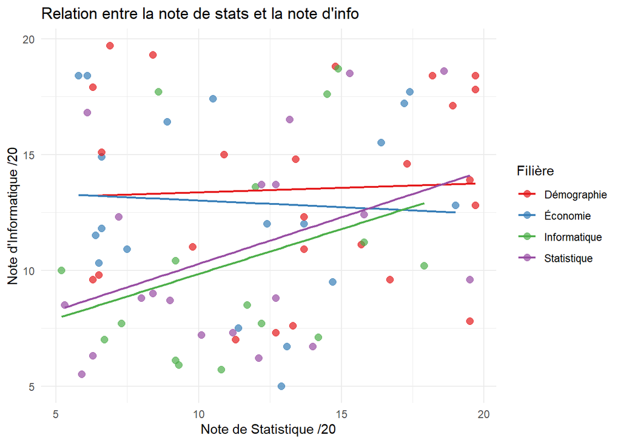

```r
ggplot(enquete, aes(x = note_stats, y = note_info, color = filiere)) +
  geom_point(alpha = 0.7, size = 2.5) +
  geom_smooth(method = "lm", se = FALSE, linewidth = 0.8) +
  scale_color_brewer(palette = "Set1") +
  labs(
    title  = "Relation entre la note de stats et la note d'info",
    x      = "Note de Statistique /20",
    y      = "Note d'Informatique /20",
    color  = "Filière"
  ) +
  theme_minimal()
```

## 5.6 Graphique en courbes avec `geom_line()`

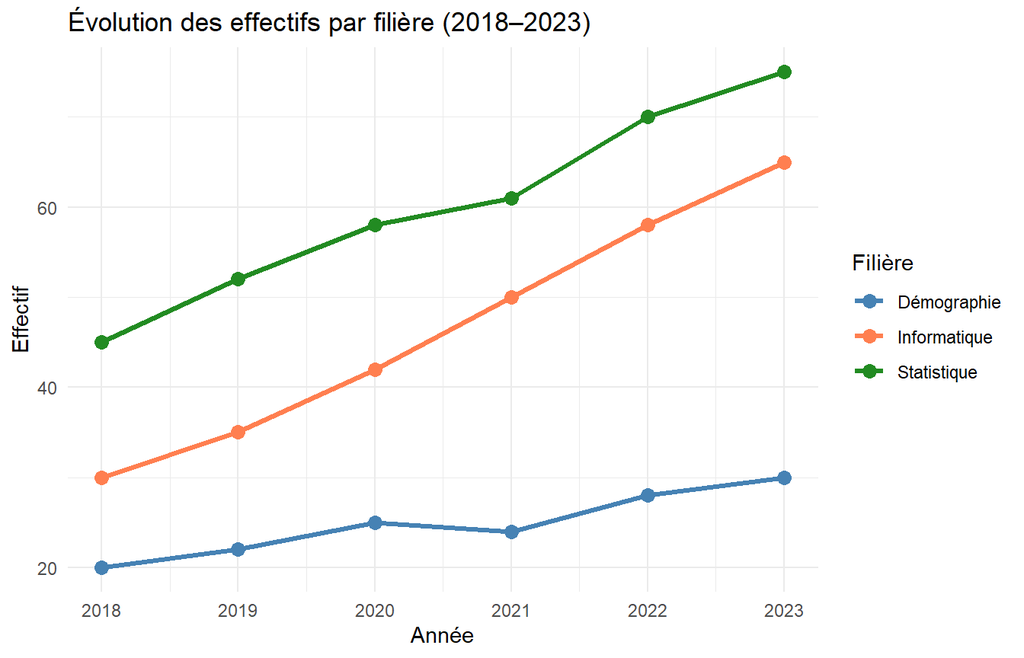

```r
# Données temporelles simulées
evolution <- tibble(
  annee      = rep(2018:2023, 3),
  filiere    = rep(c("Statistique", "Informatique", "Démographie"), each = 6),
  effectif   = c(45, 52, 58, 61, 70, 75,
                 30, 35, 42, 50, 58, 65,
                 20, 22, 25, 24, 28, 30)
)

ggplot(evolution, aes(x = annee, y = effectif, color = filiere, group = filiere)) +
  geom_line(linewidth = 1.2) +
  geom_point(size = 3) +
  scale_color_manual(values = c("steelblue", "coral", "forestgreen")) +
  labs(
    title  = "Évolution des effectifs par filière (2018–2023)",
    x      = "Année",
    y      = "Effectif",
    color  = "Filière"
  ) +
  theme_minimal() +
  scale_x_continuous(breaks = 2018:2023)
```

## 5.7 Graphique à barres empilées (%)

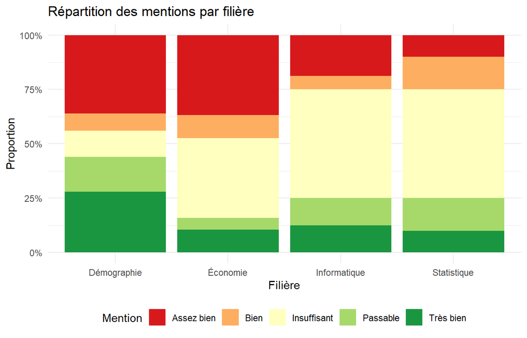

```r
ggplot(enquete, aes(x = filiere, fill = mention)) +
  geom_bar(position = "fill") +
  scale_y_continuous(labels = scales::percent) +
  scale_fill_brewer(palette = "RdYlGn", direction = 1) +
  labs(
    title = "Répartition des mentions par filière",
    x     = "Filière",
    y     = "Proportion",
    fill  = "Mention"
  ) +
  theme_minimal() +
  theme(legend.position = "bottom")
```

## 5.8 `facet_wrap()` — Graphiques en facettes

Les facettes permettent de répéter le même graphique pour chaque modalité d’une variable.

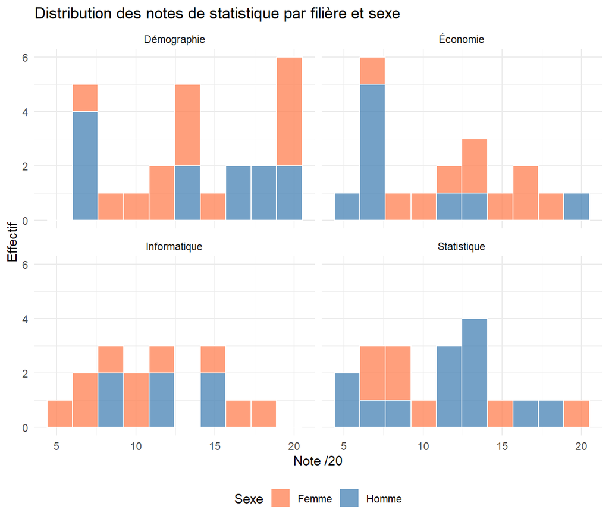

```r
ggplot(enquete, aes(x = note_stats, fill = sexe)) +
  geom_histogram(bins = 10, alpha = 0.75, color = "white") +
  facet_wrap(~ filiere, ncol = 2) +
  scale_fill_manual(values = c("Homme" = "steelblue", "Femme" = "coral")) +
  labs(
    title = "Distribution des notes de statistique par filière et sexe",
    x     = "Note /20",
    y     = "Effectif",
    fill  = "Sexe"
  ) +
  theme_minimal() +
  theme(legend.position = "bottom")
```

## 5.9 Personnalisation avancée des thèmes

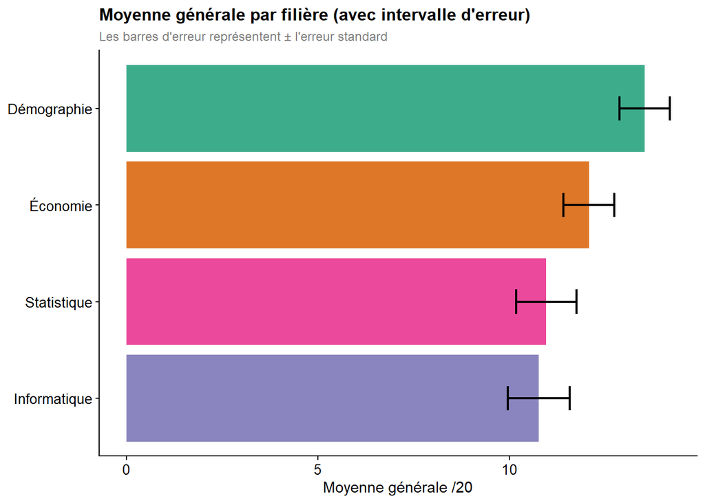

```r
ggplot(enquete, aes(x = fct_reorder(filiere, moyenne, .fun = mean),
                    y = moyenne, fill = filiere)) +
  stat_summary(fun = mean, geom = "bar", alpha = 0.85) +
  stat_summary(fun.data = mean_se, geom = "errorbar", width = 0.25, linewidth = 0.8) +
  coord_flip() +
  scale_fill_brewer(palette = "Dark2") +
  labs(
    title    = "Moyenne générale par filière (avec intervalle d'erreur)",
    subtitle = "Les barres d'erreur représentent ± l'erreur standard",
    x        = NULL,
    y        = "Moyenne générale /20"
  ) +
  theme_classic() +
  theme(
    legend.position = "none",
    plot.title      = element_text(face = "bold", size = 12),
    plot.subtitle   = element_text(color = "gray50", size = 9),
    axis.text       = element_text(size = 10)
  )
```

**AstuceLes thèmes prédéfinis de ggplot2**

| Thème | Rendu |
| --- | --- |
| `theme_minimal()` | Fond blanc, grille légère |
| `theme_classic()` | Fond blanc, axes uniquement |
| `theme_bw()` | Fond blanc, grille visible |
| `theme_dark()` | Fond sombre |
| `theme_void()` | Aucun fond ni axes |

Utilisez `theme_minimal()` ou `theme_classic()` pour des graphiques prêts pour publication.

## 5.10 Sauvegarder un graphique

```r
# Créer le graphique
mon_graphique <- ggplot(enquete, aes(x = filiere, y = moyenne)) +
  geom_boxplot(fill = "steelblue", alpha = 0.7) +
  theme_minimal() +
  labs(title = "Moyennes par filière")

# Sauvegarder en PNG haute résolution
ggsave(
  filename = "graphique_moyennes.png",
  plot     = mon_graphique,
  width    = 8,
  height   = 5,
  dpi      = 300
)

# Sauvegarder en PDF (vectoriel, pour publications)
ggsave("graphique_moyennes.pdf", mon_graphique, width = 8, height = 5)
```

# 6 Statistiques univariées et bivariées

## 6.1 Statistiques univariées avec les fonctions de base

### 6.1.1 Variables quantitatives

```r
# Utilisons le jeu de données enquete déjà créé
x <- enquete$moyenne

# Mesures de tendance centrale
cat("=== Tendance centrale ===\n")
```

```
=== Tendance centrale ===
```

```r
cat("Moyenne   :", round(mean(x), 2), "\n")
```

```
Moyenne   : 12
```

```r
cat("Médiane   :", round(median(x), 2), "\n")
```

```
Médiane   : 12.1
```

```r
cat("Mode      :", names(sort(table(round(x)), decreasing = TRUE)[1]), "\n")
```

```
Mode      : 9
```

```r
# Mesures de dispersion
cat("\n=== Dispersion ===\n")
```

```
=== Dispersion ===
```

```r
cat("Écart-type:", round(sd(x), 2), "\n")
```

```
Écart-type: 3.39
```

```r
cat("Variance  :", round(var(x), 2), "\n")
```

```
Variance  : 11.5
```

```r
cat("Étendue   :", max(x) - min(x), "\n")
```

```
Étendue   : 13.35
```

```r
cat("IQR       :", IQR(x), "\n")
```

```
IQR       : 4.875
```

```r
# Quantiles
cat("\n=== Quantiles ===\n")
```

```
=== Quantiles ===
```

```r
print(round(quantile(x, probs = c(0, 0.25, 0.5, 0.75, 1)), 2))
```

```
   0%   25%   50%   75%  100%
 5.70  9.19 12.10 14.06 19.05
```

```r
# Résumé complet en une commande
summary(enquete$moyenne)
```

```
   Min. 1st Qu.  Median    Mean 3rd Qu.    Max.
  5.700   9.188  12.100  11.996  14.062  19.050
```

### 6.1.2 Asymétrie et aplatissement

```r
install.packages("e1071")
```

```r
library(e1071)

cat("Asymétrie (skewness) :", round(skewness(enquete$moyenne), 3), "\n")
```

```
Asymétrie (skewness) : 0.295
```

```r
cat("Aplatissement (kurtosis) :", round(kurtosis(enquete$moyenne), 3), "\n")
```

```
Aplatissement (kurtosis) : -0.899
```

**NoteInterpréter l’asymétrie**

- **Skewness ≈ 0** : distribution symétrique
- **Skewness > 0** : queue à droite (asymétrie positive)
- **Skewness < 0** : queue à gauche (asymétrie négative)

### 6.1.3 Variables qualitatives

```r
# Fréquences absolues
table(enquete$filiere)
```

```
 Démographie     Économie Informatique  Statistique
          25           19           16           20
```

```r
# Fréquences relatives (%)
round(prop.table(table(enquete$filiere)) * 100, 1)
```

```
 Démographie     Économie Informatique  Statistique
        31.2         23.8         20.0         25.0
```

```r
# Avec dplyr (plus lisible)
enquete |>
  count(filiere) |>
  mutate(
    pct   = round(n / sum(n) * 100, 1),
    cum_n = cumsum(n),
    cum_pct = cumsum(pct)
  )
```

```
# A tibble: 4 × 5
  filiere          n   pct cum_n cum_pct
  <chr>        <int> <dbl> <int>   <dbl>
1 Démographie     25  31.2    25    31.2
2 Informatique    16  20      41    51.2
3 Statistique     20  25      61    76.2
4 Économie        19  23.8    80   100
```

## 6.2 Statistiques bivariées

### 6.2.1 Deux variables qualitatives — Tableau croisé

```r
# Tableau de contingence
tab <- table(enquete$filiere, enquete$sexe)
tab
```

```
               Femme Homme
  Démographie     13    12
  Économie        10     9
  Informatique    10     6
  Statistique      7    13
```

```r
# En pourcentages ligne (profil ligne)
round(prop.table(tab, margin = 1) * 100, 1)
```

```
               Femme Homme
  Démographie   52.0  48.0
  Économie      52.6  47.4
  Informatique  62.5  37.5
  Statistique   35.0  65.0
```

```r
# En pourcentages colonne (profil colonne)
round(prop.table(tab, margin = 2) * 100, 1)
```

```
               Femme Homme
  Démographie   32.5  30.0
  Économie      25.0  22.5
  Informatique  25.0  15.0
  Statistique   17.5  32.5
```

```r
# Test du chi-2 d'indépendance
test_chi2 <- chisq.test(tab)
test_chi2
```

```
    Pearson's Chi-squared test

data:  tab
X-squared = 2.8926, df = 3, p-value = 0.4085
```

```r
# Interpréter le résultat
cat("Valeur du chi-2 :", round(test_chi2$statistic, 3), "\n")
```

```
Valeur du chi-2 : 2.893
```

```r
cat("Degrés de liberté :", test_chi2$parameter, "\n")
```

```
Degrés de liberté : 3
```

```r
cat("p-valeur :", round(test_chi2$p.value, 4), "\n")
```

```
p-valeur : 0.4085
```

```r
if (test_chi2$p.value < 0.05) {
  cat("Conclusion : Lien significatif entre filière et sexe (α = 5%)\n")
} else {
  cat("Conclusion : Pas de lien significatif (α = 5%)\n")
}
```

```
Conclusion : Pas de lien significatif (α = 5%)
```

### 6.2.2 Une qualitative × une quantitative — Comparaison de groupes

```r
# Moyenne par groupe
enquete |>
  group_by(filiere) |>
  summarise(
    n   = n(),
    moy = round(mean(moyenne), 2),
    et  = round(sd(moyenne), 2),
    med = round(median(moyenne), 2)
  )
```

```
# A tibble: 4 × 5
  filiere          n   moy    et   med
  <chr>        <int> <dbl> <dbl> <dbl>
1 Démographie     25  13.5  3.28  13.3
2 Informatique    16  10.8  3.23  10.0
3 Statistique     20  11.0  3.53  10.0
4 Économie        19  12.1  2.92  12.1
```

```r
# Test de Kruskal-Wallis (alternative non paramétrique à l'ANOVA)
kruskal.test(moyenne ~ filiere, data = enquete)
```

```
    Kruskal-Wallis rank sum test

data:  moyenne by filiere
Kruskal-Wallis chi-squared = 9.0226, df = 3, p-value = 0.02899
```

```r
# Comparaison Homme vs Femme (test de Wilcoxon)
wilcox.test(moyenne ~ sexe, data = enquete)
```

```
    Wilcoxon rank sum exact test

data:  moyenne by sexe
W = 777, p-value = 0.8277
alternative hypothesis: true location shift is not equal to 0
```

### 6.2.3 Deux variables quantitatives — Corrélation

```r
# Corrélation de Pearson
cor_val <- cor(enquete$note_stats, enquete$note_info, method = "pearson")
cat("Corrélation de Pearson (stats ~ info) :", round(cor_val, 3), "\n")
```

```
Corrélation de Pearson (stats ~ info) : 0.196
```

```r
# Test de significativité
cor.test(enquete$note_stats, enquete$note_info)
```

```
    Pearson's product-moment correlation

data:  enquete$note_stats and enquete$note_info
t = 1.7617, df = 78, p-value = 0.08204
alternative hypothesis: true correlation is not equal to 0
95 percent confidence interval:
 -0.02518251  0.39821810
sample estimates:
      cor
0.1956167
```

```r
# Matrice de corrélations
vars_quant <- enquete |> select(note_stats, note_info, heures_travail, moyenne, age)
cor_matrix <- round(cor(vars_quant, method = "pearson"), 2)
cor_matrix
```

```
               note_stats note_info heures_travail moyenne   age
note_stats           1.00      0.20           0.15    0.78 -0.06
note_info            0.20      1.00          -0.03    0.77  0.03
heures_travail       0.15     -0.03           1.00    0.07  0.15
moyenne              0.78      0.77           0.07    1.00 -0.02
age                 -0.06      0.03           0.15   -0.02  1.00
```

**NoteInterpréter le coefficient de corrélation**

|  | r |
| --- | --- |
| 0.00 – 0.10 | Nulle ou négligeable |
| 0.10 – 0.30 | Faible |
| 0.30 – 0.50 | Modérée |
| 0.50 – 0.70 | Forte |
| 0.70 – 1.00 | Très forte |

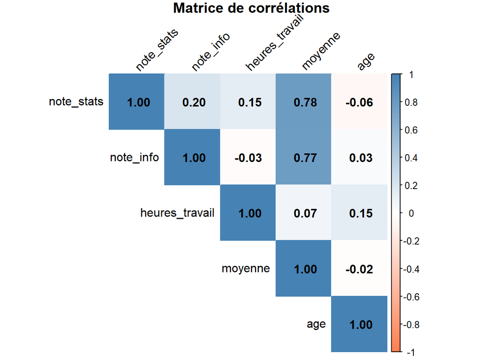

```r
# Visualisation de la matrice de corrélations
# Installation si nécessaire : install.packages("corrplot")
library(corrplot)

corrplot(cor_matrix,
         method  = "color",
         type    = "upper",
         addCoef.col = "black",
         tl.col  = "black",
         tl.srt  = 45,
         col     = colorRampPalette(c("coral", "white", "steelblue"))(200),
         title   = "Matrice de corrélations",
         mar     = c(0, 0, 1, 0))
```

# 7 Quelques fonctions utiles de R

## 7.1 Fonctions sur les chaînes de caractères — `stringr`

```r
library(stringr)

noms <- c("Adjoa Mensah", "kofi ATSU", "aminata Diallo", "BRICE Hounsa")

# Mise en forme
str_to_upper(noms)         # TOUT EN MAJUSCULES
```

```
[1] "ADJOA MENSAH"   "KOFI ATSU"      "AMINATA DIALLO" "BRICE HOUNSA"
```

```r
str_to_lower(noms)         # tout en minuscules
```

```
[1] "adjoa mensah"   "kofi atsu"      "aminata diallo" "brice hounsa"
```

```r
str_to_title(noms)         # Première Lettre En Majuscule
```

```
[1] "Adjoa Mensah"   "Kofi Atsu"      "Aminata Diallo" "Brice Hounsa"
```

```r
# Longueur des chaînes
str_length(noms)
```

```
[1] 12  9 14 12
```

```r
# Détecter un motif
str_detect(noms, "a")     # Contient la lettre "a" ?
```

```
[1]  TRUE FALSE  TRUE  TRUE
```

```r
# Extraire une sous-chaîne
str_sub(noms, 1, 5)       # 5 premiers caractères
```

```
[1] "Adjoa" "kofi " "amina" "BRICE"
```

```r
# Remplacer
str_replace(noms, "Adjoa", "Akosua")
```

```
[1] "Akosua Mensah"  "kofi ATSU"      "aminata Diallo" "BRICE Hounsa"
```

```r
# Diviser une chaîne
str_split("Adjoa Mensah", " ")[[1]]
```

```
[1] "Adjoa"  "Mensah"
```

```r
# Coller des chaînes
str_c("Étudiant", 1:5, sep = "_")
```

```
[1] "Étudiant_1" "Étudiant_2" "Étudiant_3" "Étudiant_4" "Étudiant_5"
```

```r
# Supprimer les espaces inutiles
str_trim("   Brice Hounsa   ")
```

```
[1] "Brice Hounsa"
```

```r
# Compter les occurrences d'un motif
str_count(noms, "a")
```

```
[1] 2 0 4 1
```

## 7.2 Fonctions mathématiques et de transformation

```r
x <- c(4.567, 3.142, 9.999, 1.001, 7.5)

# Arrondis
round(x, 2)          # arrondi à 2 décimales
```

```
[1]  4.57  3.14 10.00  1.00  7.50
```

```r
floor(x)             # arrondi vers le bas
```

```
[1] 4 3 9 1 7
```

```r
ceiling(x)           # arrondi vers le haut
```

```
[1]  5  4 10  2  8
```

```r
trunc(x)             # partie entière (vers zéro)
```

```
[1] 4 3 9 1 7
```

```r
# Transformations mathématiques
log(x)               # logarithme naturel
```

```
[1] 1.5188565342 1.1448595398 2.3024850880 0.0009995003 2.0149030205
```

```r
log10(x)             # logarithme base 10
```

```
[1] 0.6596310116 0.4972061807 0.9999565684 0.0004340775 0.8750612634
```

```r
exp(x)               # exponentielle
```

```
[1]    96.254911    23.150121 22004.450339     2.721001  1808.042414
```

```r
abs(c(-3, 5, -2, 7)) # valeur absolue
```

```
[1] 3 5 2 7
```

```r
# Cumul et rang
valeurs <- c(10, 25, 8, 17, 30, 12)
cumsum(valeurs)      # somme cumulée
```

```
[1]  10  35  43  60  90 102
```

```r
cumprod(c(1,2,3,4))  # produit cumulé
```

```
[1]  1  2  6 24
```

```r
cummax(valeurs)      # maximum cumulé
```

```
[1] 10 25 25 25 30 30
```

```r
rank(valeurs)        # rang de chaque valeur
```

```
[1] 2 5 1 4 6 3
```

## 7.3 Fonctions sur les vecteurs et data frames

```r
# Identifier les valeurs uniques
villes <- c("Cotonou", "Parakou", "Cotonou", "Porto-Novo", "Parakou", "Cotonou")
unique(villes)         # valeurs distinctes
```

```
[1] "Cotonou"    "Parakou"    "Porto-Novo"
```

```r
duplicated(villes)     # TRUE si doublon
```

```
[1] FALSE FALSE  TRUE FALSE  TRUE  TRUE
```

```r
table(villes)          # fréquences
```

```
villes
   Cotonou    Parakou Porto-Novo
         3          2          1
```

```r
# Valeurs manquantes
x_na <- c(3, NA, 7, NA, 5, 9)
is.na(x_na)            # Identifier les NA
```

```
[1] FALSE  TRUE FALSE  TRUE FALSE FALSE
```

```r
sum(is.na(x_na))       # Compter les NA
```

```
[1] 2
```

```r
mean(x_na, na.rm = TRUE)  # Calculer en ignorant les NA
```

```
[1] 6
```

```r
na.omit(x_na)          # Supprimer les NA
```

```
[1] 3 7 5 9
attr(,"na.action")
[1] 2 4
attr(,"class")
[1] "omit"
```

```r
# Remplacer les NA
x_na[is.na(x_na)] <- 0   # Remplacer par 0
x_na
```

```
[1] 3 0 7 0 5 9
```

```r
# Avec dplyr : replace_na()
enquete_na <- tibble(age = c(20, NA, 22, NA, 25))
enquete_na |> mutate(age = replace_na(age, mean(age, na.rm = TRUE)))
```

```
# A tibble: 5 × 1
    age
  <dbl>
1  20
2  22.3
3  22
4  22.3
5  25
```

## 7.4 Conditions : `if`, `ifelse()`, `case_when()`

```r
# if simple (pour un seul test)
note <- 13.5
if (note >= 10) {
  cat("Admis\n")
} else {
  cat("Ajourné\n")
}
```

```
Admis
```

```r
# ifelse() vectorisé (pour un vecteur)
notes <- c(14, 9, 12, 7, 15, 11)
statut <- ifelse(notes >= 10, "Admis", "Ajourné")
statut
```

```
[1] "Admis"   "Ajourné" "Admis"   "Ajourné" "Admis"   "Admis"
```

```r
# case_when() de dplyr : conditions multiples
notes_df <- tibble(note = c(18, 15, 13, 11, 8))
notes_df |>
  mutate(
    mention = case_when(
      note >= 16 ~ "Très bien",
      note >= 14 ~ "Bien",
      note >= 12 ~ "Assez bien",
      note >= 10 ~ "Passable",
      TRUE       ~ "Insuffisant"
    )
  )
```

```
# A tibble: 5 × 2
   note mention
  <dbl> <chr>
1    18 Très bien
2    15 Bien
3    13 Assez bien
4    11 Passable
5     8 Insuffisant
```

## 7.5 Boucles `for` et fonctions `apply`

```r
# Boucle for : répéter une opération
for (i in 1:5) {
  cat("Itération", i, "— carré =", i^2, "\n")
}
```

```
Itération 1 — carré = 1
Itération 2 — carré = 4
Itération 3 — carré = 9
Itération 4 — carré = 16
Itération 5 — carré = 25
```

```r
# sapply() : appliquer une fonction à chaque élément
matieres <- list(
  stats = c(14, 12, 16, 11, 15),
  info  = c(13, 15, 10, 17, 12),
  demo  = c(11, 14, 13, 15, 12)
)

sapply(matieres, mean)
```

```
stats  info  demo
 13.6  13.4  13.0
```

```r
sapply(matieres, sd)
```

```
   stats     info     demo
2.073644 2.701851 1.581139
```

```r
# lapply() : retourne une liste
lapply(matieres, summary)
```

```
$stats
   Min. 1st Qu.  Median    Mean 3rd Qu.    Max.
   11.0    12.0    14.0    13.6    15.0    16.0

$info
   Min. 1st Qu.  Median    Mean 3rd Qu.    Max.
   10.0    12.0    13.0    13.4    15.0    17.0

$demo
   Min. 1st Qu.  Median    Mean 3rd Qu.    Max.
     11      12      13      13      14      15
```

```r
# apply() : sur une matrice (lignes ou colonnes)
mat <- matrix(c(14, 12, 16, 11, 13, 15, 10, 17, 11, 14, 13, 15), nrow = 4)
apply(mat, 1, mean)  # moyenne par ligne
```

```
[1] 12.66667 13.66667 13.00000 14.33333
```

```r
apply(mat, 2, mean)  # moyenne par colonne
```

```
[1] 13.25 13.75 13.25
```

## 7.6 Créer ses propres fonctions

```r
# Structure d'une fonction
ma_fonction <- function(argument1, argument2 = valeur_defaut) {
  # Corps de la fonction
  resultat <- argument1 + argument2
  return(resultat)
}
```

```r
# Fonction : taux de réussite
taux_reussite <- function(notes, seuil = 10) {
  n_total  <- length(notes)
  n_admis  <- sum(notes >= seuil)
  taux     <- round(n_admis / n_total * 100, 1)
  cat("Total :", n_total, "| Admis :", n_admis, "| Taux :", taux, "%\n")
  return(invisible(taux))
}

# Application
notes_classe <- c(14, 9, 12, 7, 15, 11, 8, 16, 10, 13)
taux_reussite(notes_classe)
```

```
Total : 10 | Admis : 7 | Taux : 70 %
```

```r
taux_reussite(notes_classe, seuil = 12)
```

```
Total : 10 | Admis : 5 | Taux : 50 %
```

```r
# Fonction : résumé statistique personnalisé
resume_stat <- function(x, var_name = "Variable") {
  tibble(
    variable  = var_name,
    n         = length(x[!is.na(x)]),
    n_na      = sum(is.na(x)),
    moyenne   = round(mean(x, na.rm = TRUE), 2),
    mediane   = round(median(x, na.rm = TRUE), 2),
    et        = round(sd(x, na.rm = TRUE), 2),
    min       = round(min(x, na.rm = TRUE), 2),
    max       = round(max(x, na.rm = TRUE), 2),
    q1        = round(quantile(x, 0.25, na.rm = TRUE), 2),
    q3        = round(quantile(x, 0.75, na.rm = TRUE), 2)
  )
}

# Application sur plusieurs variables
bind_rows(
  resume_stat(enquete$note_stats,  "Note Stats"),
  resume_stat(enquete$note_info,   "Note Info"),
  resume_stat(enquete$moyenne,     "Moyenne"),
  resume_stat(enquete$heures_travail, "Heures de travail")
)
```

```
# A tibble: 4 × 10
  variable              n  n_na moyenne mediane    et   min   max    q1    q3
  <chr>             <int> <int>   <dbl>   <dbl> <dbl> <dbl> <dbl> <dbl> <dbl>
1 Note Stats           80     0   12.0     12.2  4.41   5.2  19.7  7.88  15
2 Note Info            80     0   12.0     11.4  4.36   5    19.7  8.32  16.4
3 Moyenne              80     0   12       12.1  3.39   5.7  19.0  9.19  14.1
4 Heures de travail    80     0    4.16     4    2.2    1     8    2      6
```

**AstuceBonne pratique — Écrire de bonnes fonctions**

1. **Un nom explicite** : préférez `calculer_taux()` à `f()`
2. **Des arguments nommés** avec des valeurs par défaut sensées
3. **Des commentaires** expliquant le rôle de chaque argument
4. **Un `return()` explicite** pour la valeur retournée
5. **Tester** la fonction avec des cas simples avant de l’utiliser

# 8 Exercices de synthèse

**Mise en gardeExercice 1 — Manipulation avec dplyr**

À partir du jeu de données `enquete` :

1. Filtrez les étudiants de `Statistique` ou `Démographie` qui ont une moyenne ≥ 12
2. Sélectionnez uniquement les colonnes `nom` (si existante), `filiere`, `sexe`, `moyenne`, `mention`
3. Triez par `mention` puis par `moyenne` décroissante
4. Créez une nouvelle colonne `categorie_age` avec : “18-21 ans”, “22-25 ans”, “26 ans et plus”
5. Comptez le nombre d’étudiants par `filiere` et `mention`, calculez les pourcentages

**Correction :**

```r
# 1. Filtrage
enquete |>
  filter(filiere %in% c("Statistique", "Démographie"), moyenne >= 12) |>
  nrow()
```

```
[1] 25
```

```r
# 2 & 3. Sélection et tri
enquete |>
  filter(filiere %in% c("Statistique", "Démographie"), moyenne >= 12) |>
  select(filiere, sexe, moyenne, mention) |>
  arrange(mention, desc(moyenne)) |>
  head(10)
```

```
# A tibble: 10 × 4
   filiere     sexe  moyenne mention
   <chr>       <chr>   <dbl> <chr>
 1 Démographie Femme    13.8 Assez bien
 2 Démographie Femme    13.6 Assez bien
 3 Démographie Homme    13.4 Assez bien
 4 Démographie Homme    13.3 Assez bien
 5 Statistique Homme    13.2 Assez bien
 6 Démographie Homme    13.2 Assez bien
 7 Démographie Homme    13   Assez bien
 8 Démographie Femme    13.0 Assez bien
 9 Statistique Homme    13.0 Assez bien
10 Démographie Femme    12.3 Assez bien
```

```r
# 4. Catégorie d'âge
enquete <- enquete |>
  mutate(
    categorie_age = case_when(
      age <= 21 ~ "18-21 ans",
      age <= 25 ~ "22-25 ans",
      TRUE      ~ "26 ans et plus"
    )
  )
enquete |> count(categorie_age)
```

```
# A tibble: 3 × 2
  categorie_age      n
  <chr>          <int>
1 18-21 ans         20
2 22-25 ans         26
3 26 ans et plus    34
```

```r
# 5. Effectifs et % par filière et mention
enquete |>
  count(filiere, mention) |>
  group_by(filiere) |>
  mutate(pct = round(n / sum(n) * 100, 1)) |>
  arrange(filiere, desc(pct))
```

```
# A tibble: 20 × 4
# Groups:   filiere [4]
   filiere      mention         n   pct
   <chr>        <chr>       <int> <dbl>
 1 Démographie  Assez bien      9  36
 2 Démographie  Très bien       7  28
 3 Démographie  Passable        4  16
 4 Démographie  Insuffisant     3  12
 5 Démographie  Bien            2   8
 6 Informatique Insuffisant     8  50
 7 Informatique Assez bien      3  18.8
 8 Informatique Passable        2  12.5
 9 Informatique Très bien       2  12.5
10 Informatique Bien            1   6.2
11 Statistique  Insuffisant    10  50
12 Statistique  Bien            3  15
13 Statistique  Passable        3  15
14 Statistique  Assez bien      2  10
15 Statistique  Très bien       2  10
16 Économie     Assez bien      7  36.8
17 Économie     Insuffisant     7  36.8
18 Économie     Bien            2  10.5
19 Économie     Très bien       2  10.5
20 Économie     Passable        1   5.3
```

**Mise en gardeExercice 2 — Facteurs**

1. Créez un facteur ordonné `mention_f` à partir de la colonne `mention` avec les niveaux dans l’ordre croissant
2. Vérifiez les niveaux et comptez les modalités
3. Recodez les modalités en abréviations : P, AB, B, TB, INS
4. Affichez un tableau de fréquences du facteur recodé

**Correction :**

```r
# 1. Facteur ordonné
mention_f <- factor(
  enquete$mention,
  levels  = c("Insuffisant", "Passable", "Assez bien", "Bien", "Très bien"),
  ordered = TRUE
)

# 2. Niveaux et comptage
levels(mention_f)
```

```
[1] "Insuffisant" "Passable"    "Assez bien"  "Bien"        "Très bien"
```

```r
fct_count(mention_f)
```

```
# A tibble: 5 × 2
  f               n
  <ord>       <int>
1 Insuffisant    28
2 Passable       10
3 Assez bien     21
4 Bien            8
5 Très bien      13
```

```r
# 3. Recodage
mention_abreg <- fct_recode(mention_f,
  "INS" = "Insuffisant",
  "P"   = "Passable",
  "AB"  = "Assez bien",
  "B"   = "Bien",
  "TB"  = "Très bien"
)

# 4. Tableau de fréquences
table(mention_abreg)
```

```
mention_abreg
INS   P  AB   B  TB
 28  10  21   8  13
```

**Mise en gardeExercice 3 — Pivot**

Les données suivantes sont en format large. Transformez-les en format long, calculez la moyenne par matière, puis retransformez en format large.

```r
notes_large2 <- tibble(
  id       = 1:5,
  maths    = c(14, 12, 17, 9, 15),
  francais = c(13, 15, 11, 14, 12),
  histoire = c(10, 13, 14, 12, 11)
)
```

**Correction :**

```r
notes_large2 <- tibble(
  id       = 1:5,
  maths    = c(14, 12, 17, 9, 15),
  francais = c(13, 15, 11, 14, 12),
  histoire = c(10, 13, 14, 12, 11)
)

# Format long
notes_long2 <- notes_large2 |>
  pivot_longer(cols = -id, names_to = "matiere", values_to = "note")
notes_long2
```

```
# A tibble: 15 × 3
      id matiere   note
   <int> <chr>    <dbl>
 1     1 maths       14
 2     1 francais    13
 3     1 histoire    10
 4     2 maths       12
 5     2 francais    15
 6     2 histoire    13
 7     3 maths       17
 8     3 francais    11
 9     3 histoire    14
10     4 maths        9
11     4 francais    14
12     4 histoire    12
13     5 maths       15
14     5 francais    12
15     5 histoire    11
```

```r
# Moyenne par matière
notes_long2 |>
  group_by(matiere) |>
  summarise(moy = round(mean(note), 2))
```

```
# A tibble: 3 × 2
  matiere    moy
  <chr>    <dbl>
1 francais  13
2 histoire  12
3 maths     13.4
```

```r
# Retour au format large
notes_long2 |>
  pivot_wider(names_from = matiere, values_from = note)
```

```
# A tibble: 5 × 4
     id maths francais histoire
  <int> <dbl>    <dbl>    <dbl>
1     1    14       13       10
2     2    12       15       13
3     3    17       11       14
4     4     9       14       12
5     5    15       12       11
```

**Mise en gardeExercice 4 — Graphiques ggplot2**

À partir du jeu de données `enquete` :

1. Tracez un boxplot des notes de statistique selon le sexe, avec des couleurs différentes pour chaque sexe
2. Tracez un nuage de points entre `heures_travail` (axe X) et `moyenne` (axe Y) avec les points colorés par `filiere`
3. Tracez un graphique en barres de la répartition des mentions, trié du plus fréquent au moins fréquent
4. Produisez le graphique 1 en facettes par `filiere`

**Correction :**

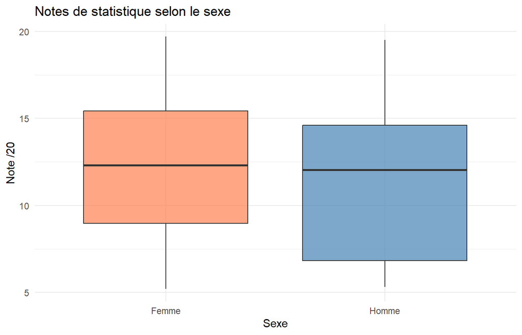

```r
# 1. Boxplot notes stats selon le sexe
ggplot(enquete, aes(x = sexe, y = note_stats, fill = sexe)) +
  geom_boxplot(alpha = 0.7) +
  scale_fill_manual(values = c("Homme" = "steelblue", "Femme" = "coral")) +
  labs(title = "Notes de statistique selon le sexe", x = "Sexe", y = "Note /20") +
  theme_minimal() +
  theme(legend.position = "none")
```

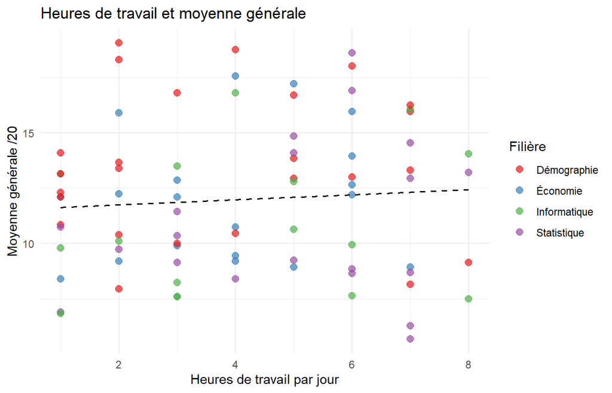

```r
# 2. Nuage de points heures ~ moyenne
ggplot(enquete, aes(x = heures_travail, y = moyenne, color = filiere)) +
  geom_point(alpha = 0.7, size = 2.5) +
  geom_smooth(method = "lm", se = FALSE, linewidth = 0.7, aes(group = 1),
              color = "black", linetype = "dashed") +
  scale_color_brewer(palette = "Set1") +
  labs(
    title  = "Heures de travail et moyenne générale",
    x      = "Heures de travail par jour",
    y      = "Moyenne générale /20",
    color  = "Filière"
  ) +
  theme_minimal()
```

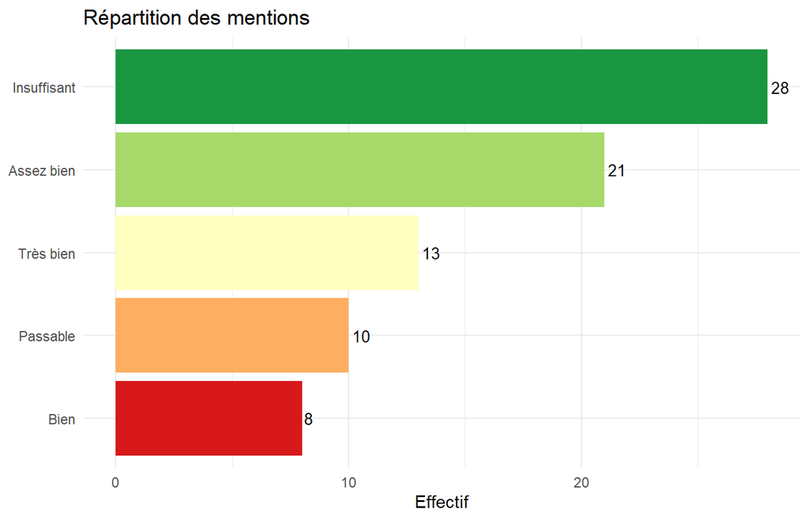

```r
# 3. Barplot mentions triées
enquete |>
  count(mention) |>
  mutate(mention = fct_reorder(mention, n)) |>
  ggplot(aes(x = mention, y = n, fill = mention)) +
  geom_col(show.legend = FALSE) +
  geom_text(aes(label = n), hjust = -0.2, size = 3.5) +
  coord_flip() +
  scale_fill_brewer(palette = "RdYlGn") +
  labs(title = "Répartition des mentions", x = NULL, y = "Effectif") +
  theme_minimal()
```

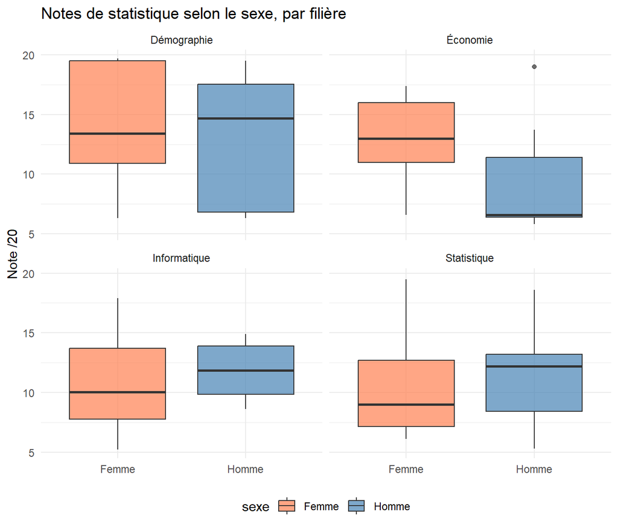

```r
# 4. Facettes par filière
ggplot(enquete, aes(x = sexe, y = note_stats, fill = sexe)) +
  geom_boxplot(alpha = 0.7) +
  facet_wrap(~ filiere, ncol = 2) +
  scale_fill_manual(values = c("Homme" = "steelblue", "Femme" = "coral")) +
  labs(
    title = "Notes de statistique selon le sexe, par filière",
    x = NULL, y = "Note /20"
  ) +
  theme_minimal() +
  theme(legend.position = "bottom")
```

**Mise en gardeExercice 5 — Statistiques bivariées**

À partir du jeu de données `enquete` :

1. Calculez la corrélation entre `heures_travail` et `moyenne` et interprétez
2. Réalisez un test du chi-2 entre `filiere` et `bourse`, interprétez le résultat
3. Comparez la moyenne de `note_stats` entre boursiers et non-boursiers avec un test adapté
4. Calculez et affichez la matrice de corrélations des variables numériques

**Correction :**

```r
# 1. Corrélation heures_travail ~ moyenne
cor_test <- cor.test(enquete$heures_travail, enquete$moyenne)
cat("Corrélation de Pearson r =", round(cor_test$estimate, 3), "\n")
```

```
Corrélation de Pearson r = 0.074
```

```r
cat("p-valeur =", round(cor_test$p.value, 4), "\n")
```

```
p-valeur = 0.5166
```

```r
if (abs(cor_test$estimate) < 0.3) cat("Intensité : faible\n") else
  if (abs(cor_test$estimate) < 0.5) cat("Intensité : modérée\n") else
    cat("Intensité : forte\n")
```

```
Intensité : faible
```

```r
# 2. Test du chi-2 filière × bourse
tab_chi2 <- table(enquete$filiere, enquete$bourse)
test <- chisq.test(tab_chi2)
cat("Chi-2 =", round(test$statistic, 3), "| ddl =", test$parameter,
    "| p-valeur =", round(test$p.value, 4), "\n")
```

```
Chi-2 = 4.499 | ddl = 3 | p-valeur = 0.2124
```

```r
if (test$p.value < 0.05) {
  cat("Conclusion : Lien significatif entre filière et bourse (α = 5%)\n")
} else {
  cat("Conclusion : Pas de lien significatif (α = 5%)\n")
}
```

```
Conclusion : Pas de lien significatif (α = 5%)
```

```r
# 3. Comparaison note_stats : boursiers vs non-boursiers
wilcox.test(note_stats ~ bourse, data = enquete)
```

```
    Wilcoxon rank sum test with continuity correction

data:  note_stats by bourse
W = 672, p-value = 1
alternative hypothesis: true location shift is not equal to 0
```

```r
# 4. Matrice de corrélations
enquete |>
  select(where(is.numeric), -id) |>
  cor(use = "complete.obs") |>
  round(2)
```

```
                 age annee note_stats note_info heures_travail moyenne
age             1.00  0.03      -0.06      0.03           0.15   -0.02
annee           0.03  1.00      -0.06     -0.01           0.09   -0.05
note_stats     -0.06 -0.06       1.00      0.20           0.15    0.78
note_info       0.03 -0.01       0.20      1.00          -0.03    0.77
heures_travail  0.15  0.09       0.15     -0.03           1.00    0.07
moyenne        -0.02 -0.05       0.78      0.77           0.07    1.00
```

**Mise en gardeExercice 6 — Fonctions personnalisées**

1. Écrivez une fonction `describe_quant(x, var_name)` qui retourne un tibble avec n, n_NA, moyenne, médiane, écart-type, Q1, Q3, IQR
2. Appliquez-la sur `note_stats`, `note_info` et `moyenne`
3. Écrivez une fonction `normaliser(x)` qui transforme un vecteur en scores standardisés : $z = \frac{x - \bar{x}}{s}$
4. Écrivez une fonction `categoriser_note(note)` qui retourne la mention selon le barème béninois (TB ≥ 16, B ≥ 14, AB ≥ 12, P ≥ 10, INS < 10)

**Correction :**

```r
# 1 & 2. Fonction describe_quant
describe_quant <- function(x, var_name = deparse(substitute(x))) {
  tibble(
    variable = var_name,
    n        = sum(!is.na(x)),
    n_NA     = sum(is.na(x)),
    moyenne  = round(mean(x, na.rm = TRUE), 2),
    mediane  = round(median(x, na.rm = TRUE), 2),
    et       = round(sd(x, na.rm = TRUE), 2),
    Q1       = round(quantile(x, 0.25, na.rm = TRUE), 2),
    Q3       = round(quantile(x, 0.75, na.rm = TRUE), 2),
    IQR      = round(IQR(x, na.rm = TRUE), 2)
  )
}

bind_rows(
  describe_quant(enquete$note_stats, "Note Stats"),
  describe_quant(enquete$note_info,  "Note Info"),
  describe_quant(enquete$moyenne,    "Moyenne")
)
```

```
# A tibble: 3 × 9
  variable       n  n_NA moyenne mediane    et    Q1    Q3   IQR
  <chr>      <int> <int>   <dbl>   <dbl> <dbl> <dbl> <dbl> <dbl>
1 Note Stats    80     0    12.0    12.2  4.41  7.88  15    7.12
2 Note Info     80     0    12.0    11.4  4.36  8.32  16.4  8.1
3 Moyenne       80     0    12      12.1  3.39  9.19  14.1  4.88
```

```r
# 3. Fonction normaliser
normaliser <- function(x) {
  (x - mean(x, na.rm = TRUE)) / sd(x, na.rm = TRUE)
}

z_scores <- normaliser(enquete$moyenne)
cat("Moyenne des z-scores :", round(mean(z_scores), 4), "\n")
```

```
Moyenne des z-scores : 0
```

```r
cat("Écart-type des z-scores :", round(sd(z_scores), 4), "\n")
```

```
Écart-type des z-scores : 1
```

```r
# 4. Fonction categoriser_note
categoriser_note <- function(note) {
  case_when(
    note >= 16 ~ "Très bien (TB)",
    note >= 14 ~ "Bien (B)",
    note >= 12 ~ "Assez bien (AB)",
    note >= 10 ~ "Passable (P)",
    TRUE       ~ "Insuffisant (INS)"
  )
}

# Test
notes_test <- c(17.5, 14.2, 12.8, 10.1, 8.5, 16.0)
categoriser_note(notes_test)
```

```
[1] "Très bien (TB)"    "Bien (B)"          "Assez bien (AB)"
[4] "Passable (P)"      "Insuffisant (INS)" "Très bien (TB)"
```

**Mise en gardeExercice 7 — Manipulation de chaînes avec `stringr`**

On dispose du vecteur suivant :

```r
codes <- c("STAT-2024-01", "DEMO-2023-07", "INFO-2024-03", "ECO-2023-12")
```

1. Extrayez la filière (3 ou 4 premiers caractères avant le tiret)
2. Extrayez l’année (4 chiffres au milieu)
3. Transformez les filieres en minuscules
4. Remplacez “STAT” par “Statistique” et “DEMO” par “Démographie”
5. Créez de nouveaux codes en remplaçant 2023 par 2025

**Correction :**

```r
library(stringr)
codes <- c("STAT-2024-01", "DEMO-2023-07", "INFO-2024-03", "ECO-2023-12")

# 1. Extraction filière
filieres_ext <- str_extract(codes, "^[A-Z]+")
filieres_ext
```

```
[1] "STAT" "DEMO" "INFO" "ECO"
```

```r
# 2. Extraction année
annees_ext <- str_extract(codes, "\\d{4}")
annees_ext
```

```
[1] "2024" "2023" "2024" "2023"
```

```r
# 3. Minuscules
str_to_lower(filieres_ext)
```

```
[1] "stat" "demo" "info" "eco"
```

```r
# 4. Remplacement
str_replace(codes, "STAT", "Statistique") |>
  str_replace("DEMO", "Démographie")
```

```
[1] "Statistique-2024-01" "Démographie-2023-07" "INFO-2024-03"
[4] "ECO-2023-12"
```

```r
# 5. Mise à jour des codes
str_replace(codes, "2023", "2025")
```

```
[1] "STAT-2024-01" "DEMO-2025-07" "INFO-2024-03" "ECO-2025-12"
```

**Mise en gardeExercice 8 — Pipeline complet**

À partir du jeu de données `enquete`, réalisez le pipeline suivant en **une seule chaîne de commandes** :

1. Filtrer les étudiants en 2ème ou 3ème année
2. Créer une variable `profil` = `filiere` + ” - ” + `sexe` (ex: “Statistique - Homme”)
3. Calculer par `profil` : effectif, moyenne, écart-type
4. Garder uniquement les profils avec au moins 3 étudiants
5. Trier par moyenne décroissante
6. Afficher le résultat

**Correction :**

```r
enquete |>
  filter(annee %in% c(2, 3)) |>
  mutate(profil = str_c(filiere, " — ", sexe)) |>
  group_by(profil) |>
  summarise(
    n   = n(),
    moy = round(mean(moyenne), 2),
    et  = round(sd(moyenne), 2),
    .groups = "drop"
  ) |>
  filter(n >= 3) |>
  arrange(desc(moy))
```

```
# A tibble: 8 × 4
  profil                   n   moy    et
  <chr>                <int> <dbl> <dbl>
1 Économie — Femme         4 14.0   2.29
2 Démographie — Femme      6 13.6   4.39
3 Informatique — Homme     4 12.2   2.91
4 Démographie — Homme      9 12.1   3.13
5 Statistique — Femme      5 12.0   3.66
6 Économie — Homme         8 11.3   2.47
7 Statistique — Homme      9 11.1   4.02
8 Informatique — Femme     8  9.42  2.84
```

**Mise en gardeExercice 9 — Visualisation avancée**

Créez un graphique qui combine :

- Un boxplot de la `moyenne` par `filiere`
- Coloré par `sexe` (côte à côte)
- Avec les points individuels superposés
- En facettes par `annee`
- Avec un titre, des labels d’axes et une légende bien positionnée

**Correction :**

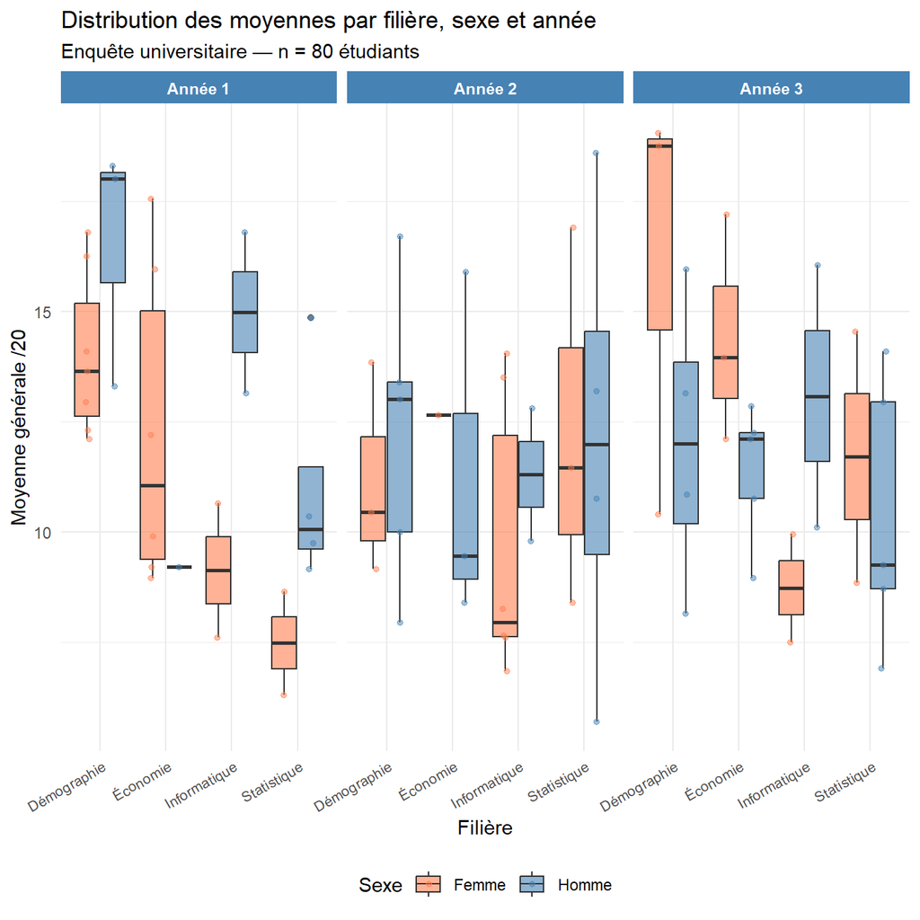

```r
ggplot(enquete, aes(x = filiere, y = moyenne, fill = sexe)) +
  geom_boxplot(alpha = 0.6, position = position_dodge(0.8)) +
  geom_jitter(aes(color = sexe),
              position = position_jitterdodge(jitter.width = 0.15, dodge.width = 0.8),
              alpha = 0.5, size = 1.2) +
  facet_wrap(~ paste("Année", annee), ncol = 3) +
  scale_fill_manual(values  = c("Homme" = "steelblue", "Femme" = "coral")) +
  scale_color_manual(values = c("Homme" = "steelblue", "Femme" = "coral")) +
  labs(
    title    = "Distribution des moyennes par filière, sexe et année",
    subtitle = "Enquête universitaire — n = 80 étudiants",
    x        = "Filière",
    y        = "Moyenne générale /20",
    fill     = "Sexe",
    color    = "Sexe"
  ) +
  theme_minimal() +
  theme(
    legend.position  = "bottom",
    axis.text.x      = element_text(angle = 30, hjust = 1, size = 8),
    strip.background = element_rect(fill = "steelblue", color = NA),
    strip.text       = element_text(color = "white", face = "bold")
  )
```

**Mise en gardeExercice 10 — Analyse complète**

Vous disposez du jeu de données suivant sur 10 communes d’un département :

```r
communes <- tibble(
  commune       = c("Parakou", "Ndali", "Sinendé", "Bembèrèkè", "Kalalé",
                    "Nikki", "Pèrèrè", "Gogounou", "Kérou", "Kouandé"),
  population    = c(255478, 56234, 82341, 95612, 78923,
                    104567, 45231, 67890, 38456, 52341),
  nb_cs         = c(12, 4, 5, 6, 5, 7, 3, 4, 3, 4),
  taux_couv_penta3 = c(92.3, 78.5, 85.2, 88.1, 72.4, 81.7, 69.8, 83.5, 65.2, 79.3),
  acces_eau     = c(TRUE, FALSE, TRUE, TRUE, FALSE, TRUE, FALSE, TRUE, FALSE, TRUE)
)
```

Réalisez :

1. Un résumé statistique complet des variables numériques
2. La corrélation entre `nb_cs` et `taux_couv_penta3`
3. La comparaison du taux de couverture selon l’accès à l’eau (`acces_eau`)
4. Un graphique nuage de points `nb_cs` ~ `taux_couv_penta3` avec les noms des communes en label
5. Un barplot horizontal du taux de couverture par commune, trié

**Correction :**

```r
communes <- tibble(
  commune       = c("Parakou", "Ndali", "Sinendé", "Bembèrèkè", "Kalalé",
                    "Nikki", "Pèrèrè", "Gogounou", "Kérou", "Kouandé"),
  population    = c(255478, 56234, 82341, 95612, 78923,
                    104567, 45231, 67890, 38456, 52341),
  nb_cs         = c(12, 4, 5, 6, 5, 7, 3, 4, 3, 4),
  taux_couv_penta3 = c(92.3, 78.5, 85.2, 88.1, 72.4, 81.7, 69.8, 83.5, 65.2, 79.3),
  acces_eau     = c(TRUE, FALSE, TRUE, TRUE, FALSE, TRUE, FALSE, TRUE, FALSE, TRUE)
)

# 1. Résumé statistique
summary(communes |> select(where(is.numeric)))
```

```
   population         nb_cs       taux_couv_penta3
 Min.   : 38456   Min.   : 3.00   Min.   :65.20
 1st Qu.: 53314   1st Qu.: 4.00   1st Qu.:73.92
 Median : 73407   Median : 4.50   Median :80.50
 Mean   : 87707   Mean   : 5.30   Mean   :79.60
 3rd Qu.: 92294   3rd Qu.: 5.75   3rd Qu.:84.78
 Max.   :255478   Max.   :12.00   Max.   :92.30
```

```r
# 2. Corrélation nb_cs ~ taux_couv_penta3
cor_res <- cor.test(communes$nb_cs, communes$taux_couv_penta3)
cat("r =", round(cor_res$estimate, 3), "| p =", round(cor_res$p.value, 4), "\n")
```

```
r = 0.728 | p = 0.0171
```

```r
# 3. Comparaison selon accès à l'eau
communes |>
  group_by(acces_eau) |>
  summarise(
    n           = n(),
    moy_taux    = round(mean(taux_couv_penta3), 1),
    med_taux    = round(median(taux_couv_penta3), 1)
  )
```

```
# A tibble: 2 × 4
  acces_eau     n moy_taux med_taux
  <lgl>     <int>    <dbl>    <dbl>
1 FALSE         4     71.5     71.1
2 TRUE          6     85       84.3
```

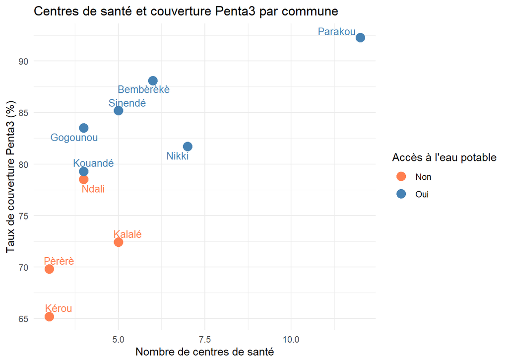

```r
# 4. Nuage de points avec labels
# install.packages("ggrepel")  # si nécessaire
library(ggrepel)

ggplot(communes, aes(x = nb_cs, y = taux_couv_penta3,
                     color = acces_eau, label = commune)) +
  geom_point(size = 4) +
  geom_text_repel(size = 3.5) +
  scale_color_manual(
    values = c("TRUE" = "steelblue", "FALSE" = "coral"),
    labels = c("TRUE" = "Oui", "FALSE" = "Non")
  ) +
  labs(
    title  = "Centres de santé et couverture Penta3 par commune",
    x      = "Nombre de centres de santé",
    y      = "Taux de couverture Penta3 (%)",
    color  = "Accès à l'eau potable"
  ) +
  theme_minimal()
```

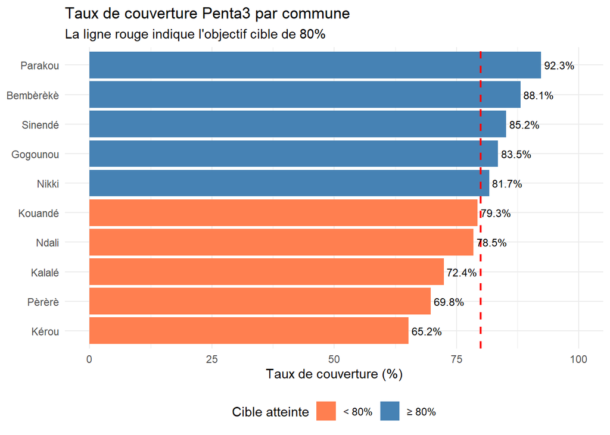

```r
# 5. Barplot horizontal trié
communes |>
  mutate(commune = fct_reorder(commune, taux_couv_penta3)) |>
  ggplot(aes(x = commune, y = taux_couv_penta3,
             fill = taux_couv_penta3 >= 80)) +
  geom_col() +
  geom_hline(yintercept = 80, linetype = "dashed", color = "red", linewidth = 0.8) +
  geom_text(aes(label = paste0(taux_couv_penta3, "%")),
            hjust = -0.1, size = 3.2) +
  coord_flip(ylim = c(0, 100)) +
  scale_fill_manual(
    values = c("TRUE" = "steelblue", "FALSE" = "coral"),
    labels = c("TRUE" = "≥ 80%", "FALSE" = "< 80%")
  ) +
  labs(
    title  = "Taux de couverture Penta3 par commune",
    subtitle = "La ligne rouge indique l'objectif cible de 80%",
    x      = NULL,
    y      = "Taux de couverture (%)",
    fill   = "Cible atteinte"
  ) +
  theme_minimal() +
  theme(legend.position = "bottom")
```

# Conclusion

## 8.1 Résumé des notions apprises

**NoteCe que vous avez maîtrisé en Séance 2**

**Tidyverse & dplyr**

- Comprendre la philosophie *tidy data* et l’opérateur pipe `|>`
- Manipuler des données avec les 5 verbes : `filter`, `select`, `mutate`, `arrange`, `summarise`
- Grouper et résumer avec `group_by()` + `summarise()`

**Structures de données avancées**

- Créer et manipuler des listes
- Pivoter les tableaux avec `pivot_longer()` et `pivot_wider()`
- Créer et retravailler des facteurs avec `factor()` et `forcats`
- Comprendre les vecteurs labellisés (`haven`)

**Visualisation avec ggplot2**

- Maîtriser la grammaire des graphiques (data + aes + geom)
- Produire : histogramme, boxplot, nuage de points, barres, courbes
- Utiliser les facettes (`facet_wrap`)
- Personnaliser les thèmes et sauvegarder

**Statistiques univariées & bivariées**

- Indicateurs de tendance centrale, dispersion, forme
- Tableau croisé, test du chi-2, corrélation de Pearson
- Tests de comparaison : Wilcoxon, Kruskal-Wallis

**Fonctions et outils**

- Manipulation de chaînes avec `stringr`
- Conditions : `ifelse()`, `case_when()`
- Itération : boucles `for`, `sapply()`, `lapply()`
- Créer ses propres fonctions

# Travail personnel

**Mise en gardeDevoir — Mini-projet d’analyse**

Collectez ou utilisez un jeu de données de votre choix (au moins 50 lignes et 5 variables, dont au moins 2 qualitatives et 2 quantitatives).

Rédigez un script R complet et annoté qui réalise :

1. **Importation** et exploration initiale (`glimpse`, `summary`, `head`)
2. **Nettoyage** : vérifier et traiter les valeurs manquantes
3. **Recodage** : créer au moins une variable recodée avec `mutate()` + `case_when()`
4. **Analyse univariée** : statistiques descriptives pour toutes les variables
5. **Analyse bivariée** : au moins un tableau croisé et une corrélation
6. **Visualisation** : au moins 3 graphiques `ggplot2` différents et commentés
7. **Synthèse** : un paragraphe de conclusions

Déposez votre script `devoir_seance2.R` avant la prochaine séance.

**AstuceRessources pour aller plus loin**

**Tidyverse & dplyr**

- [R for Data Science](https://r4ds.hadley.nz) — Chapitres 3 à 5
- [dplyr cheat sheet](https://github.com/rstudio/cheatsheets/blob/main/data-transformation.pdf)

**ggplot2**

- [ggplot2 : Elegant Graphics for Data Analysis](https://ggplot2-book.org)
- [The R Graph Gallery](https://r-graph-gallery.com) — Galerie de graphiques avec code

**Statistiques avec R**

- [Introduction à la statistique avec R](https://juba.github.io/tidyverse/) — Julien Barnier

**Aperçu de la Séance 3**

- Introduction à `Rmarkdown` / `Quarto` pour les rapports automatisés
- Régression linéaire simple et multiple
- Introduction aux modèles logistiques
- Création de tableaux de statistiques publiables avec `gtsummary`

*Document produit avec [Quarto](https://quarto.org) — Formation R, Séance 2*